# Introduction to multilevel analysis in R with `lme4` and `tidyverse`

Raffaele Vacca

University of Milan  
[raffaelevacca.com](https://www.raffaelevacca.com/)

2025-09-30

# 1 Introduction

- This is an introduction to multilevel analysis with R for my seminars at the [UniMi NASP graduate school](https://www.nasp.eu/training/phd-programmes/esls.html) and [Behave Lab](https://behavelab.org/).
- **Download these materials** [here](https://github.com/raffaelevacca/Intro-multilevel-with-R) (GitHub).

**R packages and references**:

- I focus on (1) the [`lme4`](https://github.com/lme4/lme4) package for (Restricted) Maximum Likelihood Estimation of linear multilevel models (Bates et al. 2015; Bates 2012) and (2) integrating `lme4` with the [`tidyverse`](https://www.tidyverse.org/), a collection of R packages for data science (including `dplyr`, `ggplot2`, and `purrr`) with a common language and set of principles (Wickham and Grolemund 2017).
- I draw from the discussion of (linear) multilevel modeling by Fox and Weisberg (2018) and Fox (2016b). The example used in these materials is originally by Raudenbush and Bryk (2002). Part of the code is also inspired to Wickham and Grolemund’s (2017) treatment of statistical modeling with R (particularly in Ch. 20).
- The data come from the [`MathAchieve`](https://rdrr.io/cran/nlme/man/MathAchieve.html) and [`MathAchSchool`](https://rdrr.io/cran/nlme/man/MathAchSchool.html) data frames in the [`nlme`](https://cran.r-project.org/web/packages/nlme/index.html) package. They derive from the “High School and Beyond” survey of 7185 students in 160 U.S. high schools, including 70 Catholic and 90 public schools (Fox 2016b; Raudenbush and Bryk 2002). See the links and references above for more documentation on these data.

**Further readings and resources**:

- For statistical theory, details about estimation methods, and more in-depth overall treatment of the multilevel models presented in this introduction (in chronological order): Raudenbush and Bryk (2002); Gelman and Hill (2006); Rasbash, Steele, and Reckie (2008); Goldstein (2010); Snijders and Bosker (2012); Simonoff, Scott, and Marx (2013); Fox (2016a) (Ch. 23-24).
- For more information about the R implementation of multilevel models, including different packages and estimation methods: Finch, Bolin, and Kelley (2014); Fox and Weisberg (2018); [Ben Bolker](https://math.mcmaster.ca/~bolker/)’s [FAQ page](http://bbolker.github.io/mixedmodels-misc/glmmFAQ.html#introduction) about Generalized Linear Mixed Models.

## 1.1 Setup instructions

To take this workshop you need to:

1. Download the last version of **R** [here](https://cran.r-project.org/mirrors.html) (select a location near you).
   - Follow instructions to install R on your computer.
2. Download **RStudio** (free version) [here](https://www.rstudio.com/products/rstudio/download/).
   - Follow instructions to install RStudio in your computer.
3. Install the **R packages** listed below.
   - Open RStudio and go to `Top menu > Tools > Install packages...`.
   - Install each package in the list.
4. Bring your **laptop** to the workshop.
5. Download the **workshop project folder** [here](https://github.com/raffaelevacca/Intro-multilevel-with-R)
   - Click on the link > Click on the green `Clone` button > Download ZIP > Then unzip the folder in your computer.
   - I recommend doing this in class at the beginning of the workshop so as to download the most updated version of the folder.

Once in class, go to the workshop project folder (point 5 above) and double-click on the workshop R project file (`Multilevel_with_R.Rproj`) in it. This will open RStudio.

## 1.2 Required R packages

- General
  - [`broom`](https://broom.tidymodels.org/) to view model results as tidy tibbles.
  - [`magrittr`](https://magrittr.tidyverse.org/) for pipe and related operators.
  - [`tidyverse`](https://www.tidyverse.org/)
- To fit multilevel models and view their results
  - [`broom.mixed`](https://cran.r-project.org/web/packages/broom.mixed/vignettes/broom_mixed_intro.html)
  - [`car`](https://cran.r-project.org/web/packages/car/index.html) for tests of significance.
  - [`ggeffects`](https://strengejacke.github.io/ggeffects/) to calculate and visualize predicted values.
  - [`lme4`](https://github.com/lme4/lme4) for specifying and estimating multilevel models.
  - [`lmerTest`](https://www.jstatsoft.org/article/view/v082i13) for tests of significance on multilevel models.

# 2 Explore and prepare the data

- Import and view the data in R.
- Obtain basic information about the multilevel structure of the data.
- Our dependent variable will be student’s score from math assessment (`mathach`).
- Explanatory variables:
  - Student characteristics: score of socioeconomic status (SES), in deviation from school SES mean (`ses.dev`).
  - School characteristics: school’s mean SES (`mean.ses`) and school sector (Public vs Catholic, `sector`).

```r
# Packages
library(tidyverse)
library(car)
library(lme4)
library(lmerTest)
library(ggeffects)
library(magrittr)
library(broom)
library(broom.mixed)

# Data
load("./Data/multilevel_data.rda")

# View the data
stud_data
```

```
## # A tibble: 7,185 × 5
##    school minority sex       ses mathach
##    <chr>  <fct>    <fct>   <dbl>   <dbl>
##  1 1224   No       Female -1.53    5.88
##  2 1224   No       Female -0.588  19.7
##  3 1224   No       Male   -0.528  20.3
##  4 1224   No       Male   -0.668   8.78
##  5 1224   No       Male   -0.158  17.9
##  6 1224   No       Male    0.022   4.58
##  7 1224   No       Female -0.618  -2.83
##  8 1224   No       Male   -0.998   0.523
##  9 1224   No       Female -0.888   1.53
## 10 1224   No       Male   -0.458  21.5
## # ℹ 7,175 more rows
```

```r
school_data
```

```
## # A tibble: 160 × 2
##    school sector
##  * <chr>  <fct>
##  1 1224   Public
##  2 1288   Public
##  3 1296   Public
##  4 1308   Catholic
##  5 1317   Catholic
##  6 1358   Public
##  7 1374   Public
##  8 1433   Catholic
##  9 1436   Catholic
## 10 1461   Public
## # ℹ 150 more rows
```

```r
# How many schools?
stud_data %>%
  pull(school) %>%
  n_distinct
```

```
## [1] 160
```

```r
# How many students per school (school size)?
stud_data %>%
  count(school)
```

```
## # A tibble: 160 × 2
##    school     n
##    <chr>  <int>
##  1 1224      47
##  2 1288      25
##  3 1296      48
##  4 1308      20
##  5 1317      48
##  6 1358      30
##  7 1374      28
##  8 1433      35
##  9 1436      44
## 10 1461      33
## # ℹ 150 more rows
```

```r
# Sort by school size
stud_data %>%
  count(school, sort = TRUE)
```

```
## # A tibble: 160 × 2
##    school     n
##    <chr>  <int>
##  1 2305      67
##  2 5619      66
##  3 4292      65
##  4 3610      64
##  5 4042      64
##  6 8857      64
##  7 4530      63
##  8 1477      62
##  9 2277      61
## 10 4642      61
## # ℹ 150 more rows
```

```r
# Average school size
stud_data %>%
  count(school) %>%
  summarise(mean(n))
```

```
## # A tibble: 1 × 1
##   `mean(n)`
##       <dbl>
## 1      44.9
```

```r
# Calculate mean student SES in each school
stud_data %<>%                      # Note marittr %<>% operator: pipe + assign
  group_by(school) %>%              # Group data frame by school for mutate
  mutate(mean.ses= mean(ses)) %>%   # Create mean(ses) by school
  ungroup                           # Ungroup data frame


stud_data
```

```
## # A tibble: 7,185 × 6
##    school minority sex       ses mathach mean.ses
##    <chr>  <fct>    <fct>   <dbl>   <dbl>    <dbl>
##  1 1224   No       Female -1.53    5.88    -0.434
##  2 1224   No       Female -0.588  19.7     -0.434
##  3 1224   No       Male   -0.528  20.3     -0.434
##  4 1224   No       Male   -0.668   8.78    -0.434
##  5 1224   No       Male   -0.158  17.9     -0.434
##  6 1224   No       Male    0.022   4.58    -0.434
##  7 1224   No       Female -0.618  -2.83    -0.434
##  8 1224   No       Male   -0.998   0.523   -0.434
##  9 1224   No       Female -0.888   1.53    -0.434
## 10 1224   No       Male   -0.458  21.5     -0.434
## # ℹ 7,175 more rows
```

```r
# Create student's SES deviation from school mean
(stud_data %<>%
    mutate(ses.dev = ses - mean.ses))
```

```
## # A tibble: 7,185 × 7
##    school minority sex       ses mathach mean.ses ses.dev
##    <chr>  <fct>    <fct>   <dbl>   <dbl>    <dbl>   <dbl>
##  1 1224   No       Female -1.53    5.88    -0.434 -1.09
##  2 1224   No       Female -0.588  19.7     -0.434 -0.154
##  3 1224   No       Male   -0.528  20.3     -0.434 -0.0936
##  4 1224   No       Male   -0.668   8.78    -0.434 -0.234
##  5 1224   No       Male   -0.158  17.9     -0.434  0.276
##  6 1224   No       Male    0.022   4.58    -0.434  0.456
##  7 1224   No       Female -0.618  -2.83    -0.434 -0.184
##  8 1224   No       Male   -0.998   0.523   -0.434 -0.564
##  9 1224   No       Female -0.888   1.53    -0.434 -0.454
## 10 1224   No       Male   -0.458  21.5     -0.434 -0.0236
## # ℹ 7,175 more rows
```

```r
# Join with more school-level variables (sector)
df <- left_join(stud_data, school_data, by="school")

df
```

```
## # A tibble: 7,185 × 8
##    school minority sex       ses mathach mean.ses ses.dev sector
##    <chr>  <fct>    <fct>   <dbl>   <dbl>    <dbl>   <dbl> <fct>
##  1 1224   No       Female -1.53    5.88    -0.434 -1.09   Public
##  2 1224   No       Female -0.588  19.7     -0.434 -0.154  Public
##  3 1224   No       Male   -0.528  20.3     -0.434 -0.0936 Public
##  4 1224   No       Male   -0.668   8.78    -0.434 -0.234  Public
##  5 1224   No       Male   -0.158  17.9     -0.434  0.276  Public
##  6 1224   No       Male    0.022   4.58    -0.434  0.456  Public
##  7 1224   No       Female -0.618  -2.83    -0.434 -0.184  Public
##  8 1224   No       Male   -0.998   0.523   -0.434 -0.564  Public
##  9 1224   No       Female -0.888   1.53    -0.434 -0.454  Public
## 10 1224   No       Male   -0.458  21.5     -0.434 -0.0236 Public
## # ℹ 7,175 more rows
```

```r
# Groups (school ID) should be a factor (i.e., categorical variable)
df %<>%
  mutate(school = factor(school))

# Frequencies of school sector:

# N schools
school_data %>%
  count(sector)
```

```
## # A tibble: 2 × 2
##   sector       n
##   <fct>    <int>
## 1 Public      90
## 2 Catholic    70
```

```r
# N students
df %>%
  count(sector)
```

```
## # A tibble: 2 × 2
##   sector       n
##   <fct>    <int>
## 1 Public    3642
## 2 Catholic  3543
```

- *How many students and schools are in the data?*
- *What’s the average number of students per school?*
- *How many schools are Catholic, how many are Public?*

# 3 Separate analyses by school: scatter plots

- Subset the data to a random sample of 20 Catholic schools and 20 Public schools.
- Obtain a scatter plot of student math score by student SES in each school, for the sampled Catholic and Public schools.

```r
# Sample 20 random IDs of catholic schools
set.seed(1129)
school.IDs <- school_data %>%
  filter(sector=="Catholic") %>%
  sample_n(20) %>%
  pull(school)

school.IDs
```

```
##  [1] "5667" "4223" "9198" "4253" "5650" "8150" "5761" "2658" "3838" "8193"
## [11] "4292" "7364" "3992" "5404" "5192" "1462" "4042" "3020" "7172" "1477"
```

```r
# Filter data to just those school IDs
(df.cat <- df %>%
    filter(school %in% school.IDs))
```

```
## # A tibble: 1,011 × 8
##    school minority sex      ses mathach mean.ses ses.dev sector
##    <fct>  <fct>    <fct>  <dbl>   <dbl>    <dbl>   <dbl> <fct>
##  1 1462   Yes      Male   0.162    1.97   -0.669  0.831  Catholic
##  2 1462   Yes      Male  -0.758    7.72   -0.669 -0.0886 Catholic
##  3 1462   Yes      Male  -0.708   19.0    -0.669 -0.0386 Catholic
##  4 1462   Yes      Male  -0.818   20.1    -0.669 -0.149  Catholic
##  5 1462   Yes      Male  -1.92    22.3    -0.669 -1.25   Catholic
##  6 1462   Yes      Male  -0.948   14.3    -0.669 -0.279  Catholic
##  7 1462   Yes      Male  -0.798   10.2    -0.669 -0.129  Catholic
##  8 1462   Yes      Male  -1.46     9.61   -0.669 -0.789  Catholic
##  9 1462   Yes      Male  -0.158    6.12   -0.669  0.511  Catholic
## 10 1462   Yes      Male  -0.378   23.8    -0.669  0.291  Catholic
## # ℹ 1,001 more rows
```

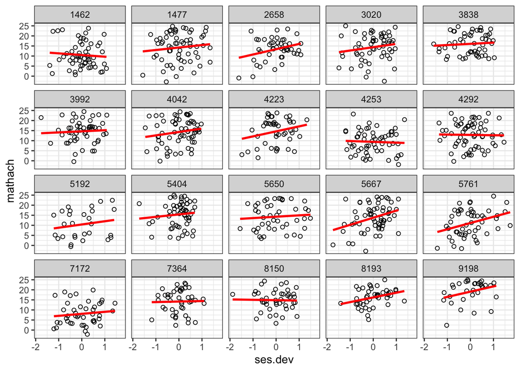

```r
# We can put everything into a single pipe to have shorter code
set.seed(1129)
df.cat <- school_data %>%
  filter(sector=="Catholic") %>%
  sample_n(20) %>%
  pull(school) %>%
  {filter(df, school %in% .)} # Note the {} brackets so that "." is not used as first argument in filter()

# Same thing for Public schools
set.seed(1129)
df.pub <- school_data %>%
  filter(sector=="Public") %>%
  sample_n(20) %>%
  pull(school) %>%
  {filter(df, school %in% .)}

# Plot SES vs math score in each of the 20 Catholic schools
# Data and variables
p <- ggplot(df.cat, aes(x=ses.dev, y=mathach)) +
  # Scatterplot geom
  geom_point(shape=1) +
  # Un-comment following line to add loess smothing line
  # geom_smooth(method="loess", color= "blue", se=FALSE) +
  # linear regression line
  geom_smooth(method="lm", color= "red", se=FALSE) +
  # Facet by school
  facet_wrap(~ school, nrow=4, ncol=5) +
  # Black/white theme
  theme_bw()

# See the plot
p
```

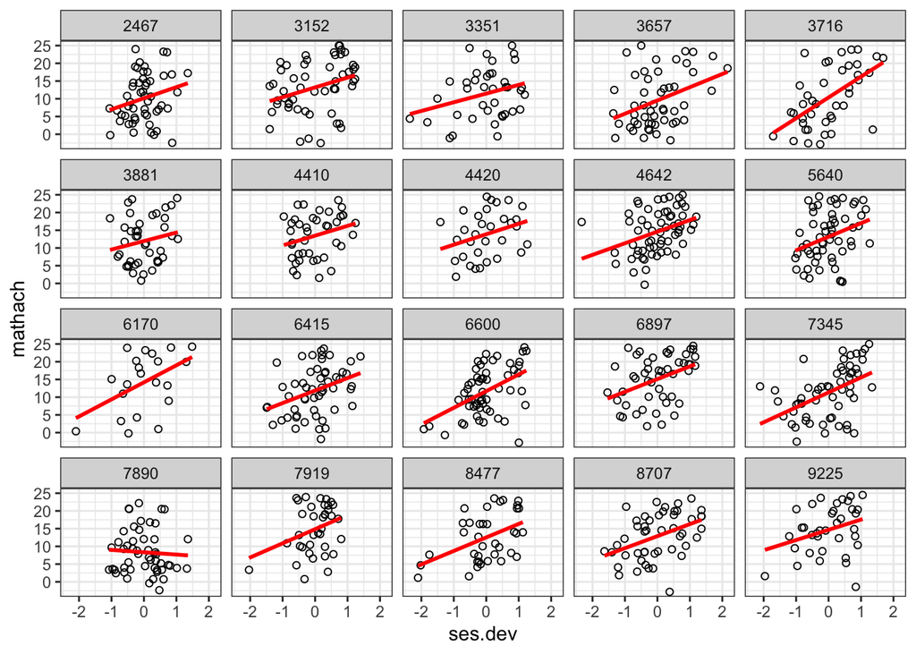

```r
# Same as above for Public schools
ggplot(df.pub, aes(x=ses.dev, y=mathach)) +
  # Scatterplot geom
  geom_point(shape=1) +
  # Un-comment following line to add loess smothing line
  # geom_smooth(method="loess", color= "blue", se=FALSE) +
  # linear regression line
  geom_smooth(method="lm", color= "red", se=FALSE) +
  # Facet by school
  facet_wrap(~ school, nrow=4, ncol=5) +
  # Black/white theme
  theme_bw()
```

- *What do you notice about intercepts and slopes of the red regression lines? Are they constant across schools?*
- *What type of relationship between student’s SES and math score do you see in schools? Does this relationship change between schools?*
- *Do you see any difference in the variability of regression lines among Catholic schools vis-a-vis Public schools?*

# 4 Separate analyses by school: linear regressions

- Create a school-level nested data frame (`nested.df`) with each school’s row including the data frame for that school’s students.
- Use `nested.df` and `purrr::map` to estimate a separate linear regression model of math achievement on SES in each school.
- Put estimation results in new columns in the nested data frame.
- Visualize estimation results:
  - Distribution of intercept and slope estimates by school sector (boxplots).
  - Distribution of intercept and slope estimates by school mean SES, by school sector (scatter plots).

```r
# Estimate a linear model for mathach as predicted by ses.dev, separately in
# each of the 160 schools.

# First, nest the student data frame by school
nested.df <- df %>%
  group_by(school) %>%
  nest()

# This creates a school-level data frame (data row = school), with each school's
# row containing the student-level data frame for that school.
nested.df
```

```
## # A tibble: 160 × 2
## # Groups:   school [160]
##    school data
##    <fct>  <list>
##  1 1224   <tibble [47 × 7]>
##  2 1288   <tibble [25 × 7]>
##  3 1296   <tibble [48 × 7]>
##  4 1308   <tibble [20 × 7]>
##  5 1317   <tibble [48 × 7]>
##  6 1358   <tibble [30 × 7]>
##  7 1374   <tibble [28 × 7]>
##  8 1433   <tibble [35 × 7]>
##  9 1436   <tibble [44 × 7]>
## 10 1461   <tibble [33 × 7]>
## # ℹ 150 more rows
```

```r
# What do the numbers of rows and columns indicate in each school's data frame?
# (e.g. [47 x 7])

# The column nested.df$data is a list of data frames, one for each school
class(nested.df$data)
```

```
## [1] "list"
```

```r
length(nested.df$data)
```

```
## [1] 160
```

```r
# For example, look at the data for school 1224:

## Still nested
nested.df %>%
  filter(school=="1224") %>%
  dplyr::select(school, data)
```

```
## # A tibble: 1 × 2
## # Groups:   school [1]
##   school data
##   <fct>  <list>
## 1 1224   <tibble [47 × 7]>
```

```r
## Unnested
nested.df %>%
  filter(school=="1224") %>%
  dplyr::select(school, data) %>%
  unnest(cols = c(data))
```

```
## # A tibble: 47 × 8
## # Groups:   school [1]
##    school minority sex       ses mathach mean.ses ses.dev sector
##    <fct>  <fct>    <fct>   <dbl>   <dbl>    <dbl>   <dbl> <fct>
##  1 1224   No       Female -1.53    5.88    -0.434 -1.09   Public
##  2 1224   No       Female -0.588  19.7     -0.434 -0.154  Public
##  3 1224   No       Male   -0.528  20.3     -0.434 -0.0936 Public
##  4 1224   No       Male   -0.668   8.78    -0.434 -0.234  Public
##  5 1224   No       Male   -0.158  17.9     -0.434  0.276  Public
##  6 1224   No       Male    0.022   4.58    -0.434  0.456  Public
##  7 1224   No       Female -0.618  -2.83    -0.434 -0.184  Public
##  8 1224   No       Male   -0.998   0.523   -0.434 -0.564  Public
##  9 1224   No       Female -0.888   1.53    -0.434 -0.454  Public
## 10 1224   No       Male   -0.458  21.5     -0.434 -0.0236 Public
## # ℹ 37 more rows
```

```r
# Or get the first element of nested.df$data
nested.df$data[[1]]
```

```
## # A tibble: 47 × 7
##    minority sex       ses mathach mean.ses ses.dev sector
##    <fct>    <fct>   <dbl>   <dbl>    <dbl>   <dbl> <fct>
##  1 No       Female -1.53    5.88    -0.434 -1.09   Public
##  2 No       Female -0.588  19.7     -0.434 -0.154  Public
##  3 No       Male   -0.528  20.3     -0.434 -0.0936 Public
##  4 No       Male   -0.668   8.78    -0.434 -0.234  Public
##  5 No       Male   -0.158  17.9     -0.434  0.276  Public
##  6 No       Male    0.022   4.58    -0.434  0.456  Public
##  7 No       Female -0.618  -2.83    -0.434 -0.184  Public
##  8 No       Male   -0.998   0.523   -0.434 -0.564  Public
##  9 No       Female -0.888   1.53    -0.434 -0.454  Public
## 10 No       Male   -0.458  21.5     -0.434 -0.0236 Public
## # ℹ 37 more rows
```

```r
# Equivalently, with tidyverse syntax
nested.df %>%
  pull(data) %>%
  extract2(1)
```

```
## # A tibble: 47 × 7
##    minority sex       ses mathach mean.ses ses.dev sector
##    <fct>    <fct>   <dbl>   <dbl>    <dbl>   <dbl> <fct>
##  1 No       Female -1.53    5.88    -0.434 -1.09   Public
##  2 No       Female -0.588  19.7     -0.434 -0.154  Public
##  3 No       Male   -0.528  20.3     -0.434 -0.0936 Public
##  4 No       Male   -0.668   8.78    -0.434 -0.234  Public
##  5 No       Male   -0.158  17.9     -0.434  0.276  Public
##  6 No       Male    0.022   4.58    -0.434  0.456  Public
##  7 No       Female -0.618  -2.83    -0.434 -0.184  Public
##  8 No       Male   -0.998   0.523   -0.434 -0.564  Public
##  9 No       Female -0.888   1.53    -0.434 -0.454  Public
## 10 No       Male   -0.458  21.5     -0.434 -0.0236 Public
## # ℹ 37 more rows
```

```r
# Using the nested data frame, we can now fit a separate linear model in each
# school's data frame (each element of nested.df$data)
lmodels <- nested.df %>%
  # Get all school data frames
  pull(data) %>%
  # Run lm() on each via map
  purrr::map(~ lm(mathach ~ ses.dev, data= .x))

# Note the formula notation in purrr::map(), where .x indicates each element of
# nested.df$data.

# lmodels is now a list of fitted linear models, one for each school
head(lmodels)
```

```
## [[1]]
##
## Call:
## lm(formula = mathach ~ ses.dev, data = .x)
##
## Coefficients:
## (Intercept)      ses.dev
##       9.715        2.509
##
##
## [[2]]
##
## Call:
## lm(formula = mathach ~ ses.dev, data = .x)
##
## Coefficients:
## (Intercept)      ses.dev
##      13.511        3.255
##
##
## [[3]]
##
## Call:
## lm(formula = mathach ~ ses.dev, data = .x)
##
## Coefficients:
## (Intercept)      ses.dev
##       7.636        1.076
##
##
## [[4]]
##
## Call:
## lm(formula = mathach ~ ses.dev, data = .x)
##
## Coefficients:
## (Intercept)      ses.dev
##      16.256        0.126
##
##
## [[5]]
##
## Call:
## lm(formula = mathach ~ ses.dev, data = .x)
##
## Coefficients:
## (Intercept)      ses.dev
##      13.178        1.274
##
##
## [[6]]
##
## Call:
## lm(formula = mathach ~ ses.dev, data = .x)
##
## Coefficients:
## (Intercept)      ses.dev
##      11.206        5.068
```

```r
class(lmodels)
```

```
## [1] "list"
```

```r
length(lmodels)
```

```
## [1] 160
```

```r
# Instead of creating this list as a separate object, we can create it as a new
# column in nested.df, adding each model to its school's row in nested.df.
nested.df %<>%
  mutate(model = purrr::map(data,
                            ~ lm(mathach ~ ses.dev, data= .x)))

# Result
nested.df
```

```
## # A tibble: 160 × 3
## # Groups:   school [160]
##    school data              model
##    <fct>  <list>            <list>
##  1 1224   <tibble [47 × 7]> <lm>
##  2 1288   <tibble [25 × 7]> <lm>
##  3 1296   <tibble [48 × 7]> <lm>
##  4 1308   <tibble [20 × 7]> <lm>
##  5 1317   <tibble [48 × 7]> <lm>
##  6 1358   <tibble [30 × 7]> <lm>
##  7 1374   <tibble [28 × 7]> <lm>
##  8 1433   <tibble [35 × 7]> <lm>
##  9 1436   <tibble [44 × 7]> <lm>
## 10 1461   <tibble [33 × 7]> <lm>
## # ℹ 150 more rows
```

```r
# The third column of nested.df ($model) now includes the fitted linear model
# for each school (each row).

# E.g., model for school 1224
nested.df %>%
  filter(school=="1224") %>%
  pull(model) %>%
  extract2(1)
```

```
##
## Call:
## lm(formula = mathach ~ ses.dev, data = .x)
##
## Coefficients:
## (Intercept)      ses.dev
##       9.715        2.509
```

```r
# Get intercept and slope for model of school 1224
nested.df %>%
  filter(school=="1224") %>%
  pull(model) %>%
  # This is needed to get the lm object out of the list object
  extract2(1) %>%
  coef
```

```
## (Intercept)     ses.dev
##    9.715447    2.508582
```

```r
# Or, for tidy output
nested.df %>%
  filter(school=="1224") %>%
  pull(model) %>%
  extract2(1) %>%
  broom::tidy()
```

```
## # A tibble: 2 × 5
##   term        estimate std.error statistic  p.value
##   <chr>          <dbl>     <dbl>     <dbl>    <dbl>
## 1 (Intercept)     9.72      1.10      8.87 1.94e-11
## 2 ses.dev         2.51      1.77      1.42 1.62e- 1
```

```r
# Let's apply the same code within mutate to get tidy estimation results for all
# models (all schools)
nested.df %<>%
  mutate(model.results = purrr::map(model,
                            broom::tidy)
  )

nested.df
```

```
## # A tibble: 160 × 4
## # Groups:   school [160]
##    school data              model  model.results
##    <fct>  <list>            <list> <list>
##  1 1224   <tibble [47 × 7]> <lm>   <tibble [2 × 5]>
##  2 1288   <tibble [25 × 7]> <lm>   <tibble [2 × 5]>
##  3 1296   <tibble [48 × 7]> <lm>   <tibble [2 × 5]>
##  4 1308   <tibble [20 × 7]> <lm>   <tibble [2 × 5]>
##  5 1317   <tibble [48 × 7]> <lm>   <tibble [2 × 5]>
##  6 1358   <tibble [30 × 7]> <lm>   <tibble [2 × 5]>
##  7 1374   <tibble [28 × 7]> <lm>   <tibble [2 × 5]>
##  8 1433   <tibble [35 × 7]> <lm>   <tibble [2 × 5]>
##  9 1436   <tibble [44 × 7]> <lm>   <tibble [2 × 5]>
## 10 1461   <tibble [33 × 7]> <lm>   <tibble [2 × 5]>
## # ℹ 150 more rows
```

```r
# Unnest to view the results
nested.df %>%
  unnest(model.results)
```

```
## # A tibble: 320 × 8
## # Groups:   school [160]
##    school data              model  term    estimate std.error statistic  p.value
##    <fct>  <list>            <list> <chr>      <dbl>     <dbl>     <dbl>    <dbl>
##  1 1224   <tibble [47 × 7]> <lm>   (Inter…    9.72      1.10     8.87   1.94e-11
##  2 1224   <tibble [47 × 7]> <lm>   ses.dev    2.51      1.77     1.42   1.62e- 1
##  3 1288   <tibble [25 × 7]> <lm>   (Inter…   13.5       1.36     9.91   9.12e-10
##  4 1288   <tibble [25 × 7]> <lm>   ses.dev    3.26      2.08     1.57   1.31e- 1
##  5 1296   <tibble [48 × 7]> <lm>   (Inter…    7.64      0.774    9.86   6.27e-13
##  6 1296   <tibble [48 × 7]> <lm>   ses.dev    1.08      1.21     0.890  3.78e- 1
##  7 1308   <tibble [20 × 7]> <lm>   (Inter…   16.3       1.40    11.6    9.02e-10
##  8 1308   <tibble [20 × 7]> <lm>   ses.dev    0.126     3.00     0.0420 9.67e- 1
##  9 1317   <tibble [48 × 7]> <lm>   (Inter…   13.2       0.790   16.7    3.97e-21
## 10 1317   <tibble [48 × 7]> <lm>   ses.dev    1.27      1.44     0.887  3.80e- 1
## # ℹ 310 more rows
```

```r
# Let's keep the part we're interested in
lm.coeff <- nested.df %>%
  unnest(model.results) %>%
  dplyr::select(school, term, estimate)

lm.coeff
```

```
## # A tibble: 320 × 3
## # Groups:   school [160]
##    school term        estimate
##    <fct>  <chr>          <dbl>
##  1 1224   (Intercept)    9.72
##  2 1224   ses.dev        2.51
##  3 1288   (Intercept)   13.5
##  4 1288   ses.dev        3.26
##  5 1296   (Intercept)    7.64
##  6 1296   ses.dev        1.08
##  7 1308   (Intercept)   16.3
##  8 1308   ses.dev        0.126
##  9 1317   (Intercept)   13.2
## 10 1317   ses.dev        1.27
## # ℹ 310 more rows
```

```r
# Reshape and rename
lm.coeff %<>%
  # Model intercept and slope into two columns
  pivot_wider(names_from = term, values_from = estimate) %>%
  # Rename columns
  dplyr::select(school, intercept = `(Intercept)`, slope = ses.dev)

lm.coeff
```

```
## # A tibble: 160 × 3
## # Groups:   school [160]
##    school intercept slope
##    <fct>      <dbl> <dbl>
##  1 1224        9.72 2.51
##  2 1288       13.5  3.26
##  3 1296        7.64 1.08
##  4 1308       16.3  0.126
##  5 1317       13.2  1.27
##  6 1358       11.2  5.07
##  7 1374        9.73 3.85
##  8 1433       19.7  1.85
##  9 1436       18.1  1.60
## 10 1461       16.8  6.27
## # ℹ 150 more rows
```

```r
# Bring school sector and mean.ses into this data frame.

# Create data frame with school ID, school sector, mean.ses
lm.df <- df %>%
  dplyr::select(school, sector, mean.ses) %>%
  distinct

lm.df
```

```
## # A tibble: 160 × 3
##    school sector   mean.ses
##    <fct>  <fct>       <dbl>
##  1 1224   Public    -0.434
##  2 1288   Public     0.122
##  3 1296   Public    -0.426
##  4 1308   Catholic   0.528
##  5 1317   Catholic   0.345
##  6 1358   Public    -0.0197
##  7 1374   Public    -0.0126
##  8 1433   Catholic   0.712
##  9 1436   Catholic   0.563
## 10 1461   Public     0.677
## # ℹ 150 more rows
```

```r
# Join with lm.coeff
(lm.df %<>%
    left_join(lm.coeff, by="school")
  )
```

```
## # A tibble: 160 × 5
##    school sector   mean.ses intercept slope
##    <fct>  <fct>       <dbl>     <dbl> <dbl>
##  1 1224   Public    -0.434       9.72 2.51
##  2 1288   Public     0.122      13.5  3.26
##  3 1296   Public    -0.426       7.64 1.08
##  4 1308   Catholic   0.528      16.3  0.126
##  5 1317   Catholic   0.345      13.2  1.27
##  6 1358   Public    -0.0197     11.2  5.07
##  7 1374   Public    -0.0126      9.73 3.85
##  8 1433   Catholic   0.712      19.7  1.85
##  9 1436   Catholic   0.563      18.1  1.60
## 10 1461   Public     0.677      16.8  6.27
## # ℹ 150 more rows
```

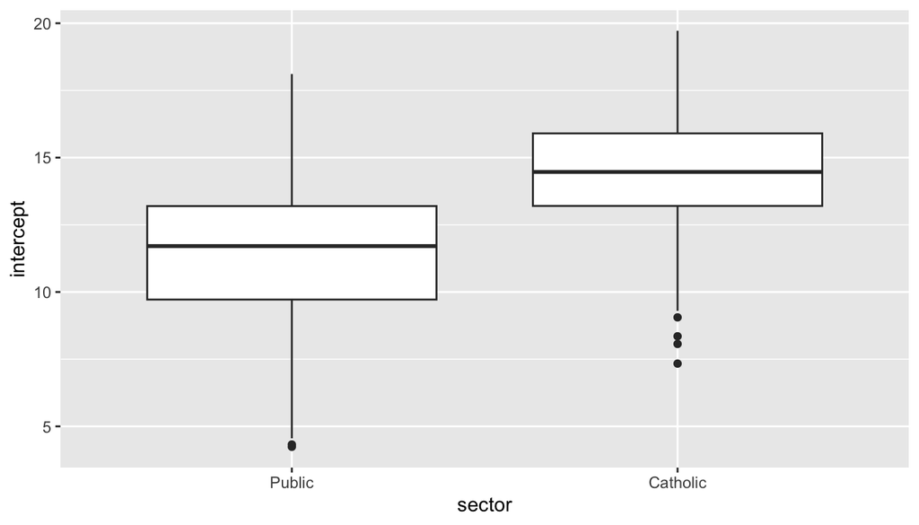

```r
# Now we can get a boxplot of school intercepts by school sector
ggplot(lm.df, aes(x= sector, y= intercept)) + geom_boxplot()
```

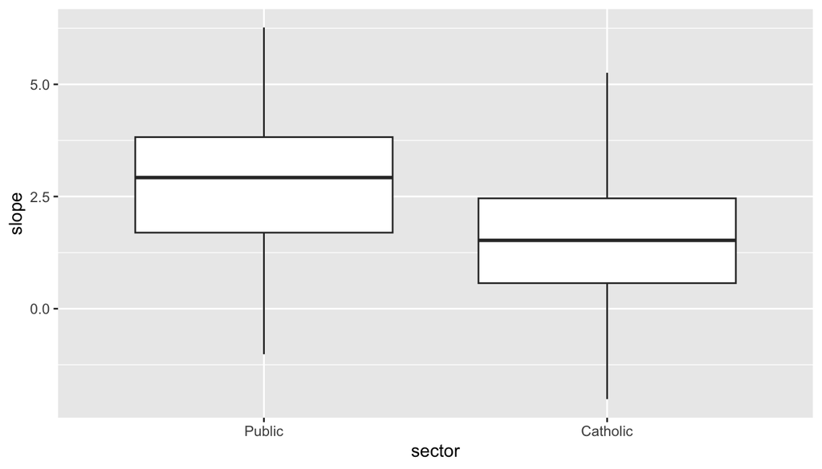

```r
# And a boxplot of school SES slopes by school sector
ggplot(lm.df, aes(x= sector, y= slope)) + geom_boxplot()
```

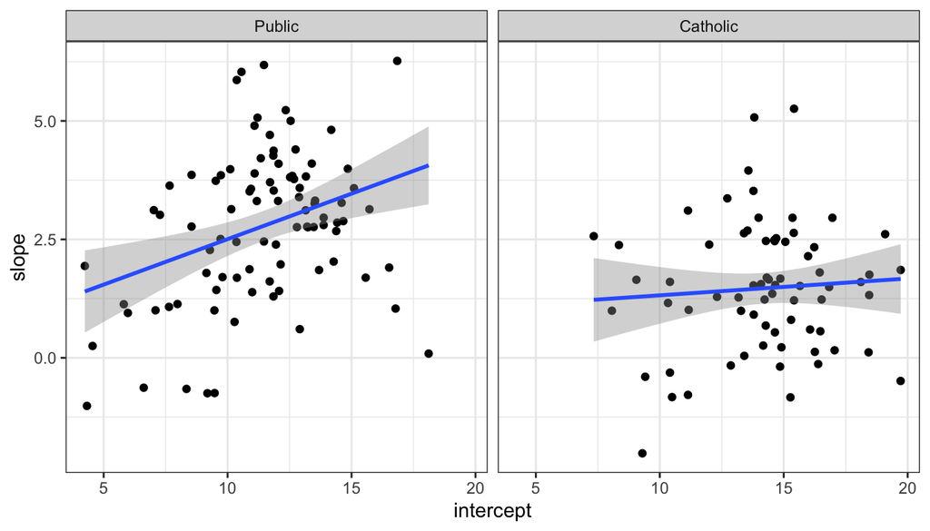

```r
# Or both sets of estimates in a scatterplot by school sector
ggplot(lm.df, aes(x= intercept, y= slope)) +
  # Scatterplot
  geom_point() +
  # Linear regression line
  geom_smooth(method="lm") +
  # Facet by sector
  facet_wrap(~ sector) +
  theme_bw()
```

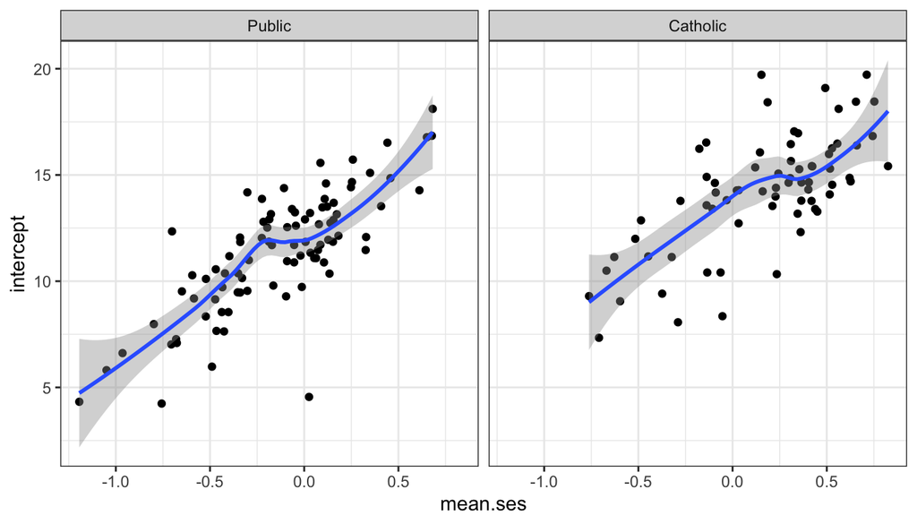

```r
# Scatterplot of school intercepts by school mean.ses, by sector
ggplot(lm.df, aes(x= mean.ses, y= intercept)) +
  geom_point() +
  geom_smooth(method="loess") +
  facet_wrap(~ sector) +
  theme_bw()
```

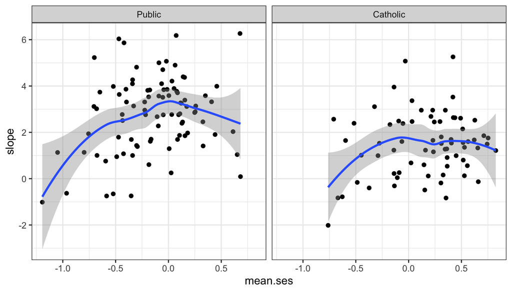

```r
# Scatterplot of school slopes by school mean.ses, by sector
ggplot(lm.df, aes(x= mean.ses, y= slope)) +
  geom_point() +
  geom_smooth(method="loess") +
  facet_wrap(~ sector) +
  theme_bw()
```

- *In `nested.df$data`, what do the numbers of rows and columns indicate in each school’s data frame?*
- *What differences do you see between the distribution of estimated *intercepts* in Public vs Catholic schools? What does this mean substantively?*
- *What differences do you see between the distribution of estimated *slopes* in Public vs Catholic schools? How do you interpret this substantively?*
- *What relationship emerges between school mean SES and school’s estimated intercept? What about the same relationship for school’s estimated slope? Are there differences between Public and Catholic schools in this respect?*

# 5 Hierarchical Linear Model: variance components

- Estimate a two-level variance components model with students (level 1) nested in schools (level 2): `mod1`.
  - This is a random-intercept model with no predictor, which simply partitions `matchach` variation between variation at the student level (between students) and variation at the school level (between schools).
  - Here `mathach` is modeled as resulting from a school random effect (group level) plus a student random effect (individual or residual level): these are called $u_i$ and $e_i$, respectively, by Rasbash, Steele, and Reckie (2008).
  - Like all models in this introduction, `mod1` is estimated via Restricted Maximum Likelihood (REML).
- Run a Likelihood Ratio Test (LRT) for the significance of school effects, comparing `mod1` with the same null linear model (no predictor) without taking into account student clustering in schools (i.e., a single-level model).
- See estimates for the variance components or random-effect parameters: the student-level variance and school-level variance – called $\sigma^2_e$ and $\sigma^2_u$, respectively, by Rasbash, Steele, and Reckie (2008).
- Use estimates for $\sigma^2_e$ and $\sigma^2_u$ to calculate the Variance Partition Coefficient (VPC):
  - This is the proportion of `mathach` variation that is attributable to the second level, that is, to between-school differences.
  - Note that in variance components models and random-intercept models (but not in random slope models) the VPC is the same as the Intraclass Correlation Coefficient (the correlation between `mathach` of two random students from the same school).

```r
# Let's start with a simple variance components model
mod1 <- lmer(mathach ~ 1 + (1 | school),
             data=df)

# Model 1 is estimated with Restricted Maximum Likelihood (REML) by default.
# You can set REML=FALSE to use Maximum Likelihood (ML) instead.

# See results.

# lmerTest augmented summary function
summary(mod1)
```

```
## Linear mixed model fit by REML. t-tests use Satterthwaite's method [
## lmerModLmerTest]
## Formula: mathach ~ 1 + (1 | school)
##    Data: df
##
## REML criterion at convergence: 47116.8
##
## Scaled residuals:
##     Min      1Q  Median      3Q     Max
## -3.0631 -0.7539  0.0267  0.7606  2.7426
##
## Random effects:
##  Groups   Name        Variance Std.Dev.
##  school   (Intercept)  8.614   2.935
##  Residual             39.148   6.257
## Number of obs: 7185, groups:  school, 160
##
## Fixed effects:
##             Estimate Std. Error       df t value Pr(>|t|)
## (Intercept)  12.6370     0.2444 156.6473   51.71   <2e-16 ***
## ---
## Signif. codes:  0 '***' 0.001 '**' 0.01 '*' 0.05 '.' 0.1 ' ' 1
```

```r
# Results in tidy format
(mod1.res <- tidy(mod1))
```

```
## # A tibble: 3 × 8
##   effect   group    term           estimate std.error statistic    df    p.value
##   <chr>    <chr>    <chr>             <dbl>     <dbl>     <dbl> <dbl>      <dbl>
## 1 fixed    <NA>     (Intercept)       12.6      0.244      51.7  157.  2.34e-100
## 2 ran_pars school   sd__(Intercep…     2.93    NA          NA     NA  NA
## 3 ran_pars Residual sd__Observati…     6.26    NA          NA     NA  NA
```

```r
# School-level variance estimate
(sigma2_u <- mod1.res %>%
    filter(effect == "ran_pars", group == "school") %>%
    # Standard deviation
    pull(estimate) %>%
    # ^2 = Variance
    .^2)
```

```
## [1] 8.614025
```

```r
# Estimate for residual, individual-level variance
(sigma2_e <- mod1.res %>%
    filter(effect == "ran_pars", group == "Residual") %>%
    # Standard deviation
    pull(estimate) %>%
    # ^2 = Variance
    .^2)
```

```
## [1] 39.14832
```

```r
# Variance Partition Coefficient
sigma2_u/(sigma2_u + sigma2_e)
```

```
## [1] 0.1803518
```

```r
# To test for significance of school effect, let's estimate a null single-level
# model
mod1_sl <- lm(mathach ~ 1,
              data=df)

# Compare the two models with Likelihood Ratio Test (LRT).
anova(mod1, mod1_sl)
```

```
## refitting model(s) with ML (instead of REML)
```

```
## Data: df
## Models:
## mod1_sl: mathach ~ 1
## mod1: mathach ~ 1 + (1 | school)
##         npar   AIC   BIC logLik deviance  Chisq Df Pr(>Chisq)
## mod1_sl    2 48104 48117 -24050    48100
## mod1       3 47122 47142 -23558    47116 983.92  1  < 2.2e-16 ***
## ---
## Signif. codes:  0 '***' 0.001 '**' 0.01 '*' 0.05 '.' 0.1 ' ' 1
```

```r
# Note that by default, anova() refits the models with ML so the LRT is correct.
```

- *How can we interpret the results from the variance components model?*
- *What proportion of `mathach` variation is explained by the school level? How does this compare with the correlation between math scores of two random students in the same school?*
- *According to the LRT, are school effects significant, that is, is the school level a significant source of variation in `mathach`?*

# 6 Hierarchical Linear Model: random intercept

- Estimate `mod2`, a random intercept model with fixed slope for individual student SES.
- See estimates for the population-level fixed effects (`Intercept` and `ses.dev` slope) and for random-effect parameters.
- This model is the same as the previous variance components model, except that `mathach` is now explained in part by individual student SES (`ses.dev`), and its unexplained variation is partitioned between individual and school random effects.
  - The VPC increases slightly compared to `mod1`, indicating that a relatively higher proportion of the (unexplained) `mathach` variation is now explained by the school level: in other words, student SES absorbs part of the student-level variation which the previous `mod1` attributed to individual random effects ($e_i$).
- There is substantial debate on if and how to calculate (and report) p-values in multilevel models:
  - See Ben Bolker’s GLMM FAQ discussion of [this issue](http://bbolker.github.io/mixedmodels-misc/glmmFAQ.html#why-doesnt-lme4-display-denominator-degrees-of-freedomp-values-what-other-options-do-i-have), and of [tests of significance](http://bbolker.github.io/mixedmodels-misc/glmmFAQ.html#testing-hypotheses) for multilevel models in general.
  - We use [`lmerTest`](https://www.jstatsoft.org/article/view/v082i13)’s modification of the `summary` function to show p-values for single coefficient estimates based on t-tests with Satterthwaite’s method.
  - But note that p-values would not by displayed if we applied the standard `summary` function to our estimated models.
  - Another option to test the significance of single coefficients is running the [`car::Anova`](https://www.rdocumentation.org/packages/car/versions/3.0-13/topics/Anova) function on the model object (see discussion by Fox and Weisberg 2018).

```r
# Random intercept model with fixed slope for individual student SES.
mod2 <- lmer(mathach ~ 1 + ses.dev + (1 | school),
             data=df)

# See results.
summary(mod2)
```

```
## Linear mixed model fit by REML. t-tests use Satterthwaite's method [
## lmerModLmerTest]
## Formula: mathach ~ 1 + ses.dev + (1 | school)
##    Data: df
##
## REML criterion at convergence: 46724
##
## Scaled residuals:
##     Min      1Q  Median      3Q     Max
## -3.0969 -0.7322  0.0194  0.7572  2.9147
##
## Random effects:
##  Groups   Name        Variance Std.Dev.
##  school   (Intercept)  8.672   2.945
##  Residual             37.010   6.084
## Number of obs: 7185, groups:  school, 160
##
## Fixed effects:
##              Estimate Std. Error        df t value Pr(>|t|)
## (Intercept)   12.6361     0.2445  156.7405   51.68   <2e-16 ***
## ses.dev        2.1912     0.1087 7022.0237   20.17   <2e-16 ***
## ---
## Signif. codes:  0 '***' 0.001 '**' 0.01 '*' 0.05 '.' 0.1 ' ' 1
##
## Correlation of Fixed Effects:
##         (Intr)
## ses.dev 0.000
```

```r
# Another option to test significance of single coefficient estimates.
Anova(mod2)
```

```
## Analysis of Deviance Table (Type II Wald chisquare tests)
##
## Response: mathach
##          Chisq Df Pr(>Chisq)
## ses.dev 406.68  1  < 2.2e-16 ***
## ---
## Signif. codes:  0 '***' 0.001 '**' 0.01 '*' 0.05 '.' 0.1 ' ' 1
```

```r
# Kenward-Roger "F" tests with Satterthwaite degrees of freedom, which in this
# case have very close results (but take much longer to calculate)
# Anova(mod2, test="F")

# Tidy results
(mod2.res <- tidy(mod2))
```

```
## # A tibble: 4 × 8
##   effect   group    term           estimate std.error statistic    df    p.value
##   <chr>    <chr>    <chr>             <dbl>     <dbl>     <dbl> <dbl>      <dbl>
## 1 fixed    <NA>     (Intercept)       12.6      0.244      51.7  157.  2.29e-100
## 2 fixed    <NA>     ses.dev            2.19     0.109      20.2 7022.  5.77e- 88
## 3 ran_pars school   sd__(Intercep…     2.94    NA          NA     NA  NA
## 4 ran_pars Residual sd__Observati…     6.08    NA          NA     NA  NA
```

```r
# See the estimates for the population-level fixed effects: intercept and SES
# slope
mod2.res %>%
  filter(effect == "fixed")
```

```
## # A tibble: 2 × 8
##   effect group term        estimate std.error statistic    df   p.value
##   <chr>  <chr> <chr>          <dbl>     <dbl>     <dbl> <dbl>     <dbl>
## 1 fixed  <NA>  (Intercept)    12.6      0.244      51.7  157. 2.29e-100
## 2 fixed  <NA>  ses.dev         2.19     0.109      20.2 7022. 5.77e- 88
```

```r
# See the estimates for the variance component parameters (aka random-effect
# parameters)
mod2.res %>%
  filter(effect == "ran_pars")
```

```
## # A tibble: 2 × 8
##   effect   group    term            estimate std.error statistic    df p.value
##   <chr>    <chr>    <chr>              <dbl>     <dbl>     <dbl> <dbl>   <dbl>
## 1 ran_pars school   sd__(Intercept)     2.94        NA        NA    NA      NA
## 2 ran_pars Residual sd__Observation     6.08        NA        NA    NA      NA
```

```r
# School-level variance estimate
(sigma2_u <- mod2.res %>%
  filter(effect == "ran_pars", group == "school") %>%
  # Standard deviation
  pull(estimate) %>%
  # ^2 = Variance
  .^2)
```

```
## [1] 8.672289
```

```r
# Residual, individual-level variance
(sigma2_e <- mod2.res %>%
    filter(effect == "ran_pars", group == "Residual") %>%
    # Standard deviation
    pull(estimate) %>%
    # ^2 = Variance
    .^2)
```

```
## [1] 37.01041
```

```r
# Variance Partition Coefficient
sigma2_u/(sigma2_u + sigma2_e)
```

```
## [1] 0.1898375
```

- *How can we interpret the estimates for the fixed-effect parameters?*
- *How can we interpret the estimates for the variance components?*
- *Based on the VPC, what proportion of the `mathach` variation *not explained* by `ses.dev` is attributable to the school level?*
  - *How does this differ from the interpretation of VPC in the variance components model `mod1`?*
  - *How can we interpret the increase in VPC compared to `mod1`?*

# 7 Hierarchical Linear Model: random slope

- Estimate `mod3`, a random slope model with in which the effect of individual student SES on math score is allowed to vary between schools.
- View estimates for the different random-effect parameters in this model: variance of random intercept, variance of random slope, covariance between random intercept and random slope.
  - These are called $\sigma^2_{u0}$, $\sigma^2_{u1}$ and $\sigma_{u01}$, respectively, by Rasbash, Steele, and Reckie (2008).
  - Note that `lme4` model results show the *correlation* $\rho_{u01}$ (not the covariance) between random intercept and random slope: to get the covariance just multiply the correlation times the two standard deviations ($\rho_{u01}*\sigma_{u0}*\sigma_{u1}$).

```r
# Random slope model with SES slope allowed to vary by school
mod3 <- lmer(mathach ~ 1 + ses.dev + (1 + ses.dev | school),
             data=df)

# Results
summary(mod3)
```

```
## Linear mixed model fit by REML. t-tests use Satterthwaite's method [
## lmerModLmerTest]
## Formula: mathach ~ 1 + ses.dev + (1 + ses.dev | school)
##    Data: df
##
## REML criterion at convergence: 46714.2
##
## Scaled residuals:
##      Min       1Q   Median       3Q      Max
## -3.09680 -0.73193  0.01855  0.75386  2.89924
##
## Random effects:
##  Groups   Name        Variance Std.Dev. Corr
##  school   (Intercept)  8.681   2.9464
##           ses.dev      0.694   0.8331   0.02
##  Residual             36.700   6.0581
## Number of obs: 7185, groups:  school, 160
##
## Fixed effects:
##             Estimate Std. Error       df t value Pr(>|t|)
## (Intercept)  12.6362     0.2445 156.7512   51.68   <2e-16 ***
## ses.dev       2.1932     0.1283 155.2166   17.10   <2e-16 ***
## ---
## Signif. codes:  0 '***' 0.001 '**' 0.01 '*' 0.05 '.' 0.1 ' ' 1
##
## Correlation of Fixed Effects:
##         (Intr)
## ses.dev 0.009
```

```r
# Tidy results
(mod3.res <- tidy(mod3))
```

```
## # A tibble: 6 × 8
##   effect   group    term           estimate std.error statistic    df    p.value
##   <chr>    <chr>    <chr>             <dbl>     <dbl>     <dbl> <dbl>      <dbl>
## 1 fixed    <NA>     (Intercept)     12.6        0.245      51.7  157.  2.29e-100
## 2 fixed    <NA>     ses.dev          2.19       0.128      17.1  155.  1.58e- 37
## 3 ran_pars school   sd__(Intercep…   2.95      NA          NA     NA  NA
## 4 ran_pars school   cor__(Interce…   0.0191    NA          NA     NA  NA
## 5 ran_pars school   sd__ses.dev      0.833     NA          NA     NA  NA
## 6 ran_pars Residual sd__Observati…   6.06      NA          NA     NA  NA
```

```r
# School-level variance of random intercept
mod3.res %>%
  filter(effect == "ran_pars", group == "school", term == "sd__(Intercept)") %>%
  # Standard deviation
  pull(estimate) %>%
  # ^2 = Variance
  .^2
```

```
## [1] 8.681044
```

```r
# School-level variance of random SES slope
mod3.res %>%
  filter(effect == "ran_pars", group == "school", term == "sd__ses.dev") %>%
  # Standard deviation
  pull(estimate) %>%
  # ^2 = Variance
  .^2
```

```
## [1] 0.6939974
```

```r
# School-level correlation between random intercept and random SES slope
mod3.res %>%
  filter(effect == "ran_pars", group == "school", term == "cor__(Intercept).ses.dev") %>%
  # Standard deviation
  pull(estimate)
```

```
## [1] 0.0190622
```

- *How many random effect parameters do we have now, compared to previous models? Why?*
- *How do we interpret the estimates for random intercept variance and random slope variance?*
- *How do we interpret the estimated correlation of random intercept and random slope?*

# 8 Contextual variables and cross-level interactions

- We may hypothesize that school random intercept and random slope are in part explained by school-level (“contextual”) variables: for example, `mean.ses` and `sector`.
  - This idea can be represented as a random-slope model with `mean.ses` and `sector` as both main effects and interactions with `ses.dev` (see derivation in slides): `mod4`.
- Alternatively, we may estimate the same model but keeping the `ses.dev` slope fixed (i.e., a random-intercept model): `mod5`.
- We test whether `mod4` explains significantly more variation in the dependent variable compared to the simpler, more parsimonious `mod5` (Likelihood Ratio Test).
  - Based on LRT results, we don’t have evidence to support the random slope (i.e., to reject the null hypothesis that the `ses.dev` slope is fixed across schools), so we choose `mod5` over `mod4`.
- From `mod5` we obtain predicted values of student `mathach` as a function of student `ses.dev`, given different contexts (i.e., different fixed values of school’s `mean.ses` and `sector`). We then plot these results.

```r
# Estimate the model
mod4 <- lmer(mathach ~ 1 + mean.ses*ses.dev + sector*ses.dev
             + (1 + ses.dev | school),
             data=df)

# See results
summary(mod4)
```

```
## Linear mixed model fit by REML. t-tests use Satterthwaite's method [
## lmerModLmerTest]
## Formula: mathach ~ 1 + mean.ses * ses.dev + sector * ses.dev + (1 + ses.dev |
##     school)
##    Data: df
##
## REML criterion at convergence: 46503.7
##
## Scaled residuals:
##      Min       1Q   Median       3Q      Max
## -3.15926 -0.72319  0.01704  0.75444  2.95822
##
## Random effects:
##  Groups   Name        Variance Std.Dev. Corr
##  school   (Intercept)  2.380   1.5426
##           ses.dev      0.101   0.3179   0.39
##  Residual             36.721   6.0598
## Number of obs: 7185, groups:  school, 160
##
## Fixed effects:
##                        Estimate Std. Error       df t value Pr(>|t|)
## (Intercept)             12.1279     0.1993 159.8955  60.856  < 2e-16 ***
## mean.ses                 5.3329     0.3692 150.9859  14.446  < 2e-16 ***
## ses.dev                  2.9450     0.1556 139.4991  18.928  < 2e-16 ***
## sectorCatholic           1.2266     0.3063 149.6127   4.005 9.74e-05 ***
## mean.ses:ses.dev         1.0393     0.2989 160.4374   3.477 0.000652 ***
## ses.dev:sectorCatholic  -1.6427     0.2398 143.2292  -6.851 2.01e-10 ***
## ---
## Signif. codes:  0 '***' 0.001 '**' 0.01 '*' 0.05 '.' 0.1 ' ' 1
##
## Correlation of Fixed Effects:
##             (Intr) men.ss ses.dv sctrCt mn.s:.
## mean.ses     0.256
## ses.dev      0.075  0.019
## sectorCthlc -0.699 -0.356 -0.053
## mn.ss:ss.dv  0.019  0.074  0.293 -0.026
## ss.dv:sctrC -0.052 -0.027 -0.696  0.077 -0.351
```

```r
tidy(mod4)
```

```
## # A tibble: 10 × 8
##    effect   group    term          estimate std.error statistic    df    p.value
##    <chr>    <chr>    <chr>            <dbl>     <dbl>     <dbl> <dbl>      <dbl>
##  1 fixed    <NA>     (Intercept)     12.1       0.199     60.9   160.  1.70e-112
##  2 fixed    <NA>     mean.ses         5.33      0.369     14.4   151.  2.95e- 30
##  3 fixed    <NA>     ses.dev          2.95      0.156     18.9   139.  2.32e- 40
##  4 fixed    <NA>     sectorCathol…    1.23      0.306      4.00  150.  9.74e-  5
##  5 fixed    <NA>     mean.ses:ses…    1.04      0.299      3.48  160.  6.52e-  4
##  6 fixed    <NA>     ses.dev:sect…   -1.64      0.240     -6.85  143.  2.01e- 10
##  7 ran_pars school   sd__(Interce…    1.54     NA         NA      NA  NA
##  8 ran_pars school   cor__(Interc…    0.391    NA         NA      NA  NA
##  9 ran_pars school   sd__ses.dev      0.318    NA         NA      NA  NA
## 10 ran_pars Residual sd__Observat…    6.06     NA         NA      NA  NA
```

```r
# Test for random slope for ses.dev: compare random intercept vs random slope
# models with same fixed effects.

# Estimate same model as mod4, but without random slope (only random intercept).
mod5 <- lmer(mathach ~ 1 + mean.ses*ses.dev + sector*ses.dev
             + (1 | school), data=df)

# See results
summary(mod5)
```

```
## Linear mixed model fit by REML. t-tests use Satterthwaite's method [
## lmerModLmerTest]
## Formula: mathach ~ 1 + mean.ses * ses.dev + sector * ses.dev + (1 | school)
##    Data: df
##
## REML criterion at convergence: 46504.8
##
## Scaled residuals:
##     Min      1Q  Median      3Q     Max
## -3.1701 -0.7249  0.0148  0.7542  2.9655
##
## Random effects:
##  Groups   Name        Variance Std.Dev.
##  school   (Intercept)  2.375   1.541
##  Residual             36.766   6.064
## Number of obs: 7185, groups:  school, 160
##
## Fixed effects:
##                         Estimate Std. Error        df t value Pr(>|t|)
## (Intercept)              12.1282     0.1992  160.0061  60.885  < 2e-16 ***
## mean.ses                  5.3367     0.3690  151.0718  14.463  < 2e-16 ***
## ses.dev                   2.9421     0.1512 7018.2611  19.457  < 2e-16 ***
## sectorCatholic            1.2245     0.3061  149.6953   4.000 9.92e-05 ***
## mean.ses:ses.dev          1.0444     0.2910 7018.2611   3.589 0.000335 ***
## ses.dev:sectorCatholic   -1.6422     0.2331 7018.2611  -7.045 2.03e-12 ***
## ---
## Signif. codes:  0 '***' 0.001 '**' 0.01 '*' 0.05 '.' 0.1 ' ' 1
##
## Correlation of Fixed Effects:
##             (Intr) men.ss ses.dv sctrCt mn.s:.
## mean.ses     0.256
## ses.dev      0.000  0.000
## sectorCthlc -0.699 -0.356  0.000
## mn.ss:ss.dv  0.000  0.000  0.295  0.000
## ss.dv:sctrC  0.000  0.000 -0.696  0.000 -0.351
```

```r
tidy(mod5)
```

```
## # A tibble: 8 × 8
##   effect   group    term           estimate std.error statistic    df    p.value
##   <chr>    <chr>    <chr>             <dbl>     <dbl>     <dbl> <dbl>      <dbl>
## 1 fixed    <NA>     (Intercept)       12.1      0.199     60.9   160.  1.40e-112
## 2 fixed    <NA>     mean.ses           5.34     0.369     14.5   151.  2.62e- 30
## 3 fixed    <NA>     ses.dev            2.94     0.151     19.5  7018.  3.58e- 82
## 4 fixed    <NA>     sectorCatholic     1.22     0.306      4.00  150.  9.92e-  5
## 5 fixed    <NA>     mean.ses:ses.…     1.04     0.291      3.59 7018.  3.35e-  4
## 6 fixed    <NA>     ses.dev:secto…    -1.64     0.233     -7.05 7018.  2.03e- 12
## 7 ran_pars school   sd__(Intercep…     1.54    NA         NA      NA  NA
## 8 ran_pars Residual sd__Observati…     6.06    NA         NA      NA  NA
```

```r
# Test for random slope: LRT comparing random slope model vs random intercept model
anova(mod5, mod4)
```

```
## refitting model(s) with ML (instead of REML)
```

```
## Data: df
## Models:
## mod5: mathach ~ 1 + mean.ses * ses.dev + sector * ses.dev + (1 | school)
## mod4: mathach ~ 1 + mean.ses * ses.dev + sector * ses.dev + (1 + ses.dev | school)
##      npar   AIC   BIC logLik deviance  Chisq Df Pr(>Chisq)
## mod5    8 46513 46568 -23249    46497
## mod4   10 46516 46585 -23248    46496 1.0016  2     0.6061
```

```r
# Based on the value of the observed Chisq statistic and its p-value, we keep
# the random intercept model with fixed slope for ses.dev: mod5

# Get mod5 predicted values by ses.dev, at different levels of school sector and
# mean.ses.
pred.val <- ggpredict(mod5, terms = c("ses.dev", "mean.ses [-1:0.5 by=0.5]", "sector")) %>%
  as_tibble() %>%
  dplyr::rename(ses.dev = x, mathach = predicted, mean.ses = group, sector = facet)

pred.val
```

```
## # A tibble: 64 × 7
##    ses.dev mathach std.error conf.low conf.high mean.ses sector
##      <dbl>   <dbl>     <dbl>    <dbl>     <dbl> <fct>    <fct>
##  1      -4  -0.799     1.20    -3.15       1.56 -1       Public
##  2      -4   6.99      1.54     3.97      10.0  -1       Catholic
##  3      -4  -0.220     0.743   -1.68       1.24 -0.5     Public
##  4      -4   7.57      1.03     5.55       9.60 -0.5     Catholic
##  5      -4   0.360     0.637   -0.889      1.61 0        Public
##  6      -4   8.15      0.706    6.77       9.54 0        Catholic
##  7      -4   0.939     1.00    -1.03       2.90 0.5      Public
##  8      -4   8.73      0.823    7.12      10.3  0.5      Catholic
##  9      -3   1.10      0.934   -0.733      2.93 -1       Public
## 10      -3   7.25      1.20     4.90       9.60 -1       Catholic
## # ℹ 54 more rows
```

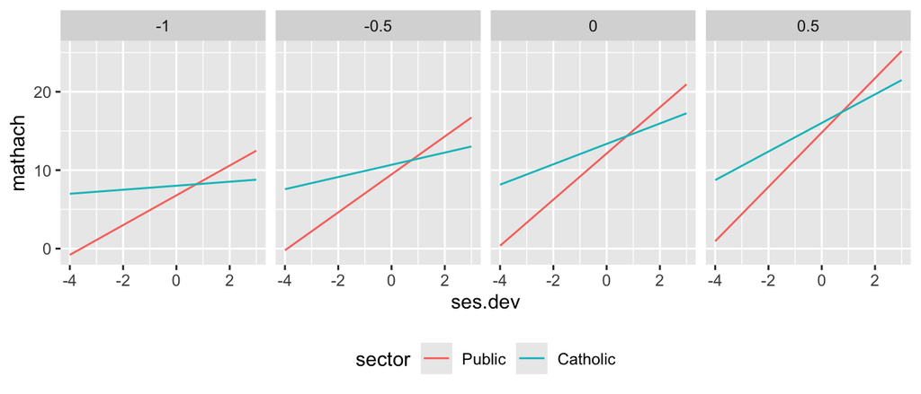

```r
# Plot these predicted effects
ggplot(pred.val) +
  # Lines of mathach by ses.dev, grouped/colored by sector (Public vs Catholic)
  geom_line(aes(y = mathach, x = ses.dev, group = sector, color = sector)) +
  # Different panels for different mean.ses values
  facet_grid(~ mean.ses) +
  theme(legend.position="bottom")
```

- *How many fixed effect parameters do we have now, compared to previous models? Why?*
- *What coefficient estimates are in `mod4` but *not* in `mod5`? Why?*
- *How do we substantively interpret results of the LRT comparing `mod4` and `mod5`?*
- *How can we interpret the visualization of predicted values from `mod5`? What is the (fixed) effect of `ses.dev` on `mathach`? How does this change in Catholic vs Public schools? How does this change in schools whose student population has higher SES on average?*

# 9 Examining school random effects and random intercepts

- Get the estimate for the fixed, population-level intercept in Public ($\beta_0$) and Catholic ($\beta_0+\beta_3$) schools (see slides for coefficient notation).
- Get estimates for the random effect of each school $j$ (called $u_j$ by Rasbash, Steele, and Reckie 2008).
- Add the fixed intercept to each $u_j$ to obtain each school’s estimated realization of the random intercept: $\beta_0+u_j$ for Public schools and $\beta_0+\beta_3+u_j$ for Catholic schools.
  - This is the school’s average math score at mean values of predictors (assuming predictors are centered).
- Identify “best” schools based on random intercept realization.
- Visualize the distribution of this random intercept and its association with school average SES (`mean.ses`) for Public and Catholic schools.

```r
# Estimated coefficients in selected model
mod5.res <- tidy(mod5)

# Get fixed parameters from model
mod5.res %>%
  filter(effect == "fixed")
```

```
## # A tibble: 6 × 8
##   effect group term                 estimate std.error statistic    df   p.value
##   <chr>  <chr> <chr>                   <dbl>     <dbl>     <dbl> <dbl>     <dbl>
## 1 fixed  <NA>  (Intercept)             12.1      0.199     60.9   160. 1.40e-112
## 2 fixed  <NA>  mean.ses                 5.34     0.369     14.5   151. 2.62e- 30
## 3 fixed  <NA>  ses.dev                  2.94     0.151     19.5  7018. 3.58e- 82
## 4 fixed  <NA>  sectorCatholic           1.22     0.306      4.00  150. 9.92e-  5
## 5 fixed  <NA>  mean.ses:ses.dev         1.04     0.291      3.59 7018. 3.35e-  4
## 6 fixed  <NA>  ses.dev:sectorCatho…    -1.64     0.233     -7.05 7018. 2.03e- 12
```

```r
# Fixed intercept
mod5.res %>%
  filter(effect == "fixed", term == "(Intercept)") %>%
  pull(estimate)
```

```
## [1] 12.12821
```

```r
# Note that because Public schools are the reference category, for Catholic
# schools (dummy variable=1) we have to add the sectorCatholic parameter to get
# the actual fixed intercept.
mod5.res %>%
  filter(effect == "fixed", term == "sectorCatholic") %>%
  pull(estimate)
```

```
## [1] 1.224529
```

```r
# Save the fixed intercepts.

# Fixed intercept for public schools.
(fixed_int_pub <- mod5.res %>%
    filter(effect == "fixed", term == "(Intercept)") %>%
    pull(estimate))
```

```
## [1] 12.12821
```

```r
# sectorCatholic fixed effect.
(fixed_slo_cat <- mod5.res %>%
  filter(effect == "fixed", term == "sectorCatholic") %>%
  pull(estimate))
```

```
## [1] 1.224529
```

```r
# Fixed intercept for Catholic schools: sum.
(fixed_int_cat <- fixed_int_pub + fixed_slo_cat)
```

```
## [1] 13.35274
```

```r
# lme4::ranef can calculate estimates (conditional modes) for the intercept random effect
# for each school
lme4::ranef(mod5) %>%
  str
```

```
## List of 1
##  $ school:'data.frame':  160 obs. of  1 variable:
##   ..$ (Intercept): num [1:160] -0.0712 0.4531 -1.6798 0.0479 -1.5259 ...
##   ..- attr(*, "postVar")= num [1, 1, 1:160] 0.588 0.908 0.579 1.036 0.579 ...
##  - attr(*, "class")= chr "ranef.mer"
```

```r
ranef(mod5)$school %>%
  head
```

```
##      (Intercept)
## 1224 -0.07116497
## 1288  0.45311618
## 1296 -1.67981589
## 1308  0.04791777
## 1317 -1.52592390
## 1358 -0.53895146
```

```r
# Save as data frame
(school.effects <- ranef(mod5)$school %>%
  as_tibble(rownames = "school") %>%
    # These are called u_j in certain textbooks.
    rename(u_j = `(Intercept)`)
    )
```

```
## # A tibble: 160 × 2
##    school     u_j
##    <chr>    <dbl>
##  1 1224   -0.0712
##  2 1288    0.453
##  3 1296   -1.68
##  4 1308    0.0479
##  5 1317   -1.53
##  6 1358   -0.539
##  7 1374   -1.50
##  8 1433    1.78
##  9 1436    1.30
## 10 1461    0.748
## # ℹ 150 more rows
```

```r
# Note that school is character in this data frame: convert to factor.
school.effects %<>%
  mutate(school = factor(school))

# Add school sector and mean.ses to the data frame of random effects.
# Remember we have these variables here:
lm.df
```

```
## # A tibble: 160 × 5
##    school sector   mean.ses intercept slope
##    <fct>  <fct>       <dbl>     <dbl> <dbl>
##  1 1224   Public    -0.434       9.72 2.51
##  2 1288   Public     0.122      13.5  3.26
##  3 1296   Public    -0.426       7.64 1.08
##  4 1308   Catholic   0.528      16.3  0.126
##  5 1317   Catholic   0.345      13.2  1.27
##  6 1358   Public    -0.0197     11.2  5.07
##  7 1374   Public    -0.0126      9.73 3.85
##  8 1433   Catholic   0.712      19.7  1.85
##  9 1436   Catholic   0.563      18.1  1.60
## 10 1461   Public     0.677      16.8  6.27
## # ℹ 150 more rows
```

```r
# Join
school.effects %<>%
  left_join(lm.df, by="school") %>%
  dplyr::select(school, u_j, sector, mean.ses)

school.effects
```

```
## # A tibble: 160 × 4
##    school     u_j sector   mean.ses
##    <fct>    <dbl> <fct>       <dbl>
##  1 1224   -0.0712 Public    -0.434
##  2 1288    0.453  Public     0.122
##  3 1296   -1.68   Public    -0.426
##  4 1308    0.0479 Catholic   0.528
##  5 1317   -1.53   Catholic   0.345
##  6 1358   -0.539  Public    -0.0197
##  7 1374   -1.50   Public    -0.0126
##  8 1433    1.78   Catholic   0.712
##  9 1436    1.30   Catholic   0.563
## 10 1461    0.748  Public     0.677
## # ℹ 150 more rows
```

```r
# Add a column with the fixed intercept estimate.
# Remember this is different for Catholic vs Public schools as per calculations
# above: we use dplyr::case_when() to set the fixed intercept estimate
# for each school depending on sector.
school.effects %<>%
  mutate(fixed.int = case_when(
    sector == "Public" ~ fixed_int_pub,
    sector == "Catholic" ~ fixed_int_cat
  ))

# View
school.effects
```

```
## # A tibble: 160 × 5
##    school     u_j sector   mean.ses fixed.int
##    <fct>    <dbl> <fct>       <dbl>     <dbl>
##  1 1224   -0.0712 Public    -0.434       12.1
##  2 1288    0.453  Public     0.122       12.1
##  3 1296   -1.68   Public    -0.426       12.1
##  4 1308    0.0479 Catholic   0.528       13.4
##  5 1317   -1.53   Catholic   0.345       13.4
##  6 1358   -0.539  Public    -0.0197      12.1
##  7 1374   -1.50   Public    -0.0126      12.1
##  8 1433    1.78   Catholic   0.712       13.4
##  9 1436    1.30   Catholic   0.563       13.4
## 10 1461    0.748  Public     0.677       12.1
## # ℹ 150 more rows
```

```r
# Now we can add the fixed intercept estimate to the school random effect estimate
# to get each school's estimated realization of the random intercept.
school.effects %<>%
  mutate(ran.int = fixed.int + u_j)

# View
school.effects
```

```
## # A tibble: 160 × 6
##    school     u_j sector   mean.ses fixed.int ran.int
##    <fct>    <dbl> <fct>       <dbl>     <dbl>   <dbl>
##  1 1224   -0.0712 Public    -0.434       12.1    12.1
##  2 1288    0.453  Public     0.122       12.1    12.6
##  3 1296   -1.68   Public    -0.426       12.1    10.4
##  4 1308    0.0479 Catholic   0.528       13.4    13.4
##  5 1317   -1.53   Catholic   0.345       13.4    11.8
##  6 1358   -0.539  Public    -0.0197      12.1    11.6
##  7 1374   -1.50   Public    -0.0126      12.1    10.6
##  8 1433    1.78   Catholic   0.712       13.4    15.1
##  9 1436    1.30   Catholic   0.563       13.4    14.7
## 10 1461    0.748  Public     0.677       12.1    12.9
## # ℹ 150 more rows
```

```r
# "Best" schools: highest value of random intercept (average math score at mean
# values of predictors).
school.effects %>%
  arrange(desc(ran.int))
```

```
## # A tibble: 160 × 6
##    school   u_j sector   mean.ses fixed.int ran.int
##    <fct>  <dbl> <fct>       <dbl>     <dbl>   <dbl>
##  1 3427    4.21 Catholic    0.153      13.4    17.6
##  2 7688    3.17 Catholic    0.186      13.4    16.5
##  3 8628    3.13 Catholic   -0.140      13.4    16.5
##  4 8193    2.81 Catholic   -0.177      13.4    16.2
##  5 9198    2.08 Catholic    0.492      13.4    15.4
##  6 2655    3.05 Public     -0.702      12.1    15.2
##  7 2629    1.80 Catholic   -0.138      13.4    15.2
##  8 1433    1.78 Catholic    0.712      13.4    15.1
##  9 4292    1.70 Catholic   -0.486      13.4    15.1
## 10 2526    1.54 Catholic    0.327      13.4    14.9
## # ℹ 150 more rows
```

```r
# Best among Catholic schools
school.effects %>%
  filter(sector=="Catholic") %>%
  arrange(desc(ran.int))
```

```
## # A tibble: 70 × 6
##    school   u_j sector   mean.ses fixed.int ran.int
##    <fct>  <dbl> <fct>       <dbl>     <dbl>   <dbl>
##  1 3427    4.21 Catholic    0.153      13.4    17.6
##  2 7688    3.17 Catholic    0.186      13.4    16.5
##  3 8628    3.13 Catholic   -0.140      13.4    16.5
##  4 8193    2.81 Catholic   -0.177      13.4    16.2
##  5 9198    2.08 Catholic    0.492      13.4    15.4
##  6 2629    1.80 Catholic   -0.138      13.4    15.2
##  7 1433    1.78 Catholic    0.712      13.4    15.1
##  8 4292    1.70 Catholic   -0.486      13.4    15.1
##  9 2526    1.54 Catholic    0.327      13.4    14.9
## 10 3838    1.50 Catholic    0.145      13.4    14.9
## # ℹ 60 more rows
```

```r
# Best among Public schools
school.effects %>%
  filter(sector=="Public") %>%
  arrange(desc(ran.int))
```

```
## # A tibble: 90 × 6
##    school   u_j sector mean.ses fixed.int ran.int
##    <fct>  <dbl> <fct>     <dbl>     <dbl>   <dbl>
##  1 2655    3.05 Public  -0.702       12.1    15.2
##  2 6170    2.11 Public  -0.302       12.1    14.2
##  3 6089    2.03 Public   0.0859      12.1    14.2
##  4 4420    1.98 Public  -0.224       12.1    14.1
##  5 8357    1.80 Public  -0.107       12.1    13.9
##  6 5640    1.55 Public  -0.177       12.1    13.7
##  7 2336    1.53 Public   0.442       12.1    13.7
##  8 1942    1.53 Public   0.682       12.1    13.7
##  9 7697    1.49 Public   0.258       12.1    13.6
## 10 4642    1.48 Public   0.115       12.1    13.6
## # ℹ 80 more rows
```

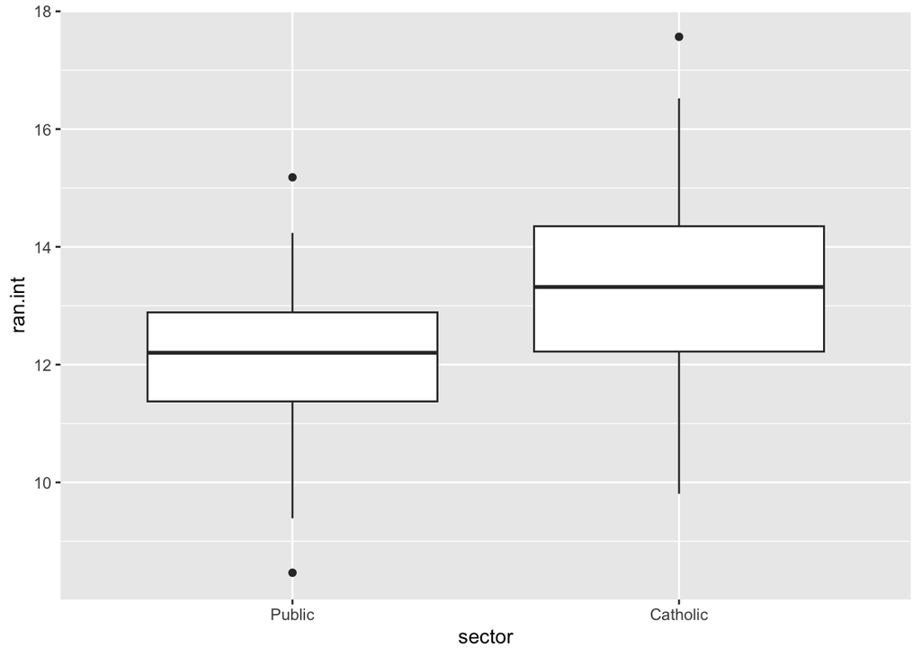

```r
# Visualize random intercept distribution by sector
ggplot(school.effects, aes(x=sector, y= ran.int)) + geom_boxplot()
```

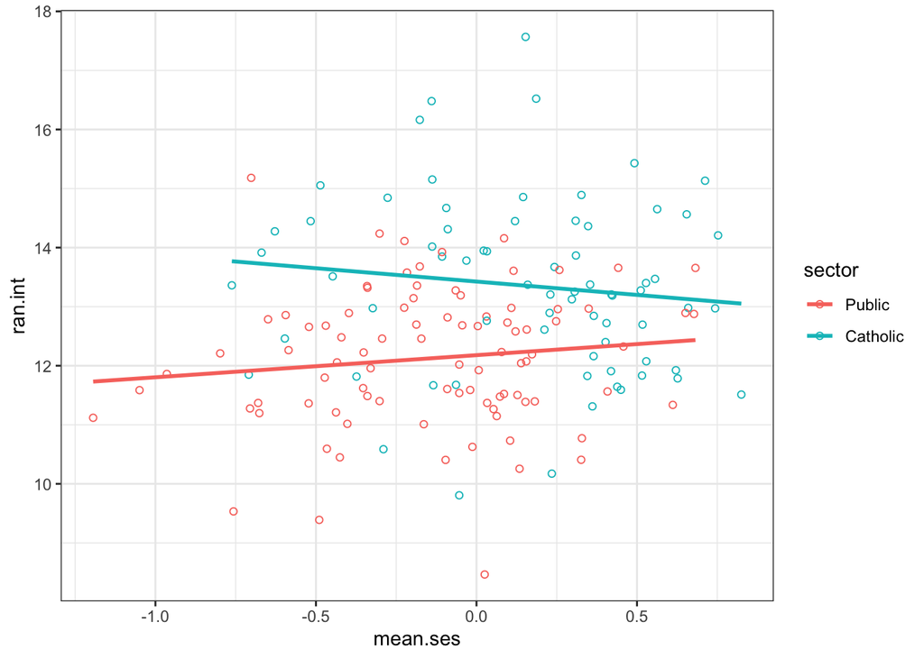

```r
# Visualize random intercepts by mean.ses in Catholic vs Public schools
ggplot(school.effects,
       aes(x=mean.ses, y=ran.int, color = sector)) +
  # Scatterplot geom
  geom_point(shape=1) +
  # linear regression line
  geom_smooth(method="lm", se=FALSE) +
  # Black/white theme
  theme_bw()
```

- *How do we interpret these last two plots?*

# 10 References

Bates, Douglas. 2012. *Lme4: Mixed-Effects Modeling with R*. https://stat.ethz.ch/~maechler/MEMo-pages/lMMwR.pdf.

Bates, Douglas, Martin Mächler, Ben Bolker, and Steve Walker. 2015. “Fitting Linear Mixed-Effects Models Using Lme4.” *Journal of Statistical Software* 67 (1). https://doi.org/10.18637/jss.v067.i01.

Finch, W. Holmes, Jocelyn E Bolin, and Ken Kelley. 2014. *Multilevel Modeling Using R*. CRC Press.

Fox, John. 2016a. *Applied Regression Analysis and Generalized Linear Models*. Third Edition. Los Angeles: SAGE.

———. 2016b. “Linear Mixed-Effects Models for Hierarchical and Longitudinal Data.” In *Applied Regression Analysis and Generalized Linear Models*, Third Edition, 700–742. Los Angeles: SAGE.

Fox, John, and Sanford Weisberg. 2018. “Fitting Mixed-Effects Models.” In *An R Companion to Applied Regression*, Third edition, 335–84. Los Angeles, Calif.: SAGE Publications, Inc.

Gelman, Andrew, and Jennifer Hill. 2006. *Data Analysis Using Regression and Multilevel/Hierarchical Models*. Cambridge ; New York: Cambridge University Press.

Goldstein, Harvey. 2010. *Multilevel Statistical Models*. 4 edition. Chichester, West Sussex: Wiley.

Rasbash, J., F. Steele, and George Reckie. 2008. *LEMMA: Learning Environment for Multilevel Methodology and Applications*. University of Bristol: Centre for Multilevel Modelling. https://www.cmm.bris.ac.uk/lemma.

Raudenbush, Stephen W., and Anthony S. Bryk. 2002. *Hierarchical Linear Models: Applications and Data Analysis Methods*. 2nd edition. Thousand Oaks: SAGE Publications, Inc.

Simonoff, Jeffrey S., Marc A. Scott, and Brian D. Marx, eds. 2013. *The SAGE Handbook of Multilevel Modeling*. Los Angeles: SAGE.

Snijders, Tom, and R. J. Bosker. 2012. *Multilevel Analysis: An Introduction to Basic and Advanced Multilevel Modeling*. 2nd edition. London; Thousand Oaks, Calif: SAGE Publications.

Wickham, Hadley, and Garrett Grolemund. 2017. *R for Data Science: Import, Tidy, Transform, Visualize, and Model Data*. 1 edition. Sebastopol, CA: O’Reilly Media. http://r4ds.had.co.nz.